# Social Network Analysis Assignment

Raghu Sanugommula and Subhash Pemmaraju

27th March 2019

### Introduction: Initial Summary

The purpose of this project is to analyze the data collected from a survey conducted by a professor in 512 class. This survey data talks about how students are connected for doing their assignments, are they pursuing careers in the same field, and how far the student is living from where the primary responder live, etc. The primary objective is to get students hands-on experience in network graphs visualization topics and gage the knowledge on how to design a compelling social networking graph, which became a dominant analytical approach for analyzing social networking data in today’s world. By completing this assignment, we are confident that we would be able to solve real-world problems related to social networking data using data visualizations techniques

### Methodology:

igraph is a library collection for creating and manipulating graphs and analyzing networks. It is widely used in academic research in network science and related fields. It can be used for large social networking analysis efficiently. The data set for this assignment consists of 17 variables and 18 observations. We will be analyzing different categories of network connections between the students. We will use the network diagrams to show relationships visually. We will use the histogram to plot the degrees vs. frequency of the student connections. Besides, we will explore various factor and numeric variables using exploratory, and I graph visualization techniques.

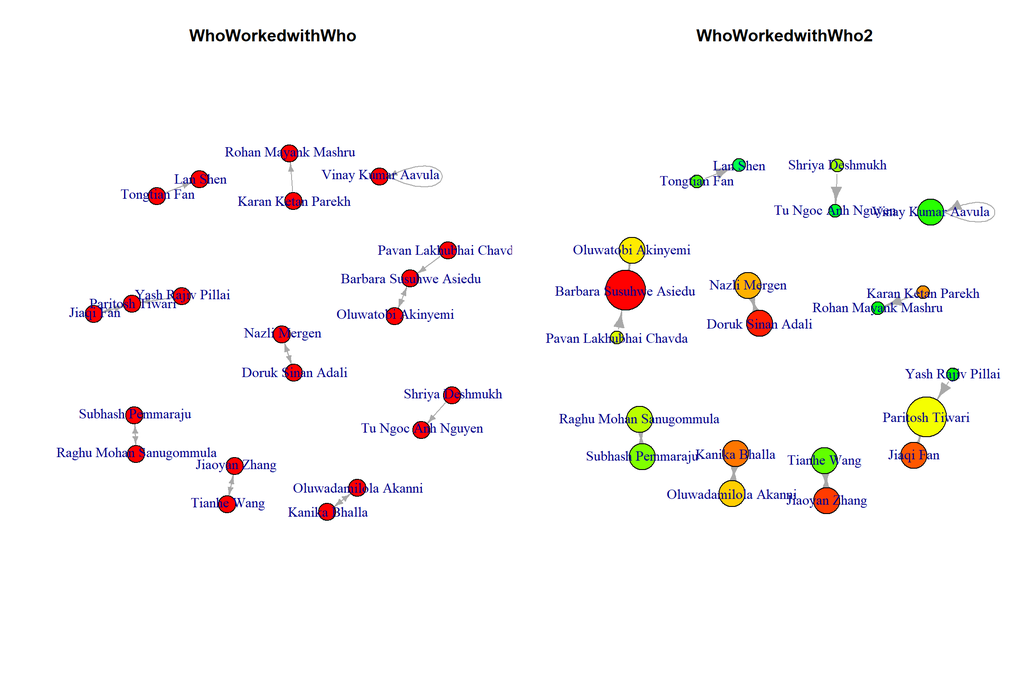

```r
par(mfrow=c(1,2))
set.seed(222)
## Network Diagram 1 ####

plot(network1,vertex.color="red",vertex.size=10,vertex.label.dist=0.1,edge.arrow.size=0.5,vertex.label.cex=1,main="WhoWorkedwithWho",layout=layout.fruchterman.reingold)

##Network Diagram2 ####

plot(network1,vertex.color=rainbow(52),vertex.size=V(network1)$degree*8,edge.arrow.size=1,layout=layout.fruchterman.reingold,main="WhoWorkedwithWho2")
```

**Figure 1 & 2**

Figure 1 and two talks relatively the same; however, it has differences in the visuals. We will talk about the differences in this section outlining the above graphs; Graph 1 is talking about who worked with who during their semester, and graph two talks about the same, but the vertices in graph two were derived from the degree of the two character variables. Besides, we tried a different color and basic format. Though there is no much to talk about these graphs since they are straightforward, however, the critical difference that should be observed in the graphs is how the data is being influencing the vertex, the more people have worked with the person, the more the size of the vertex. Also, we can observe how there are some outliers where people worked by themselves without having an assignment partner; in these cases, the arrows are pointing to themselves representing the same. That is another exciting learning from this exercise.

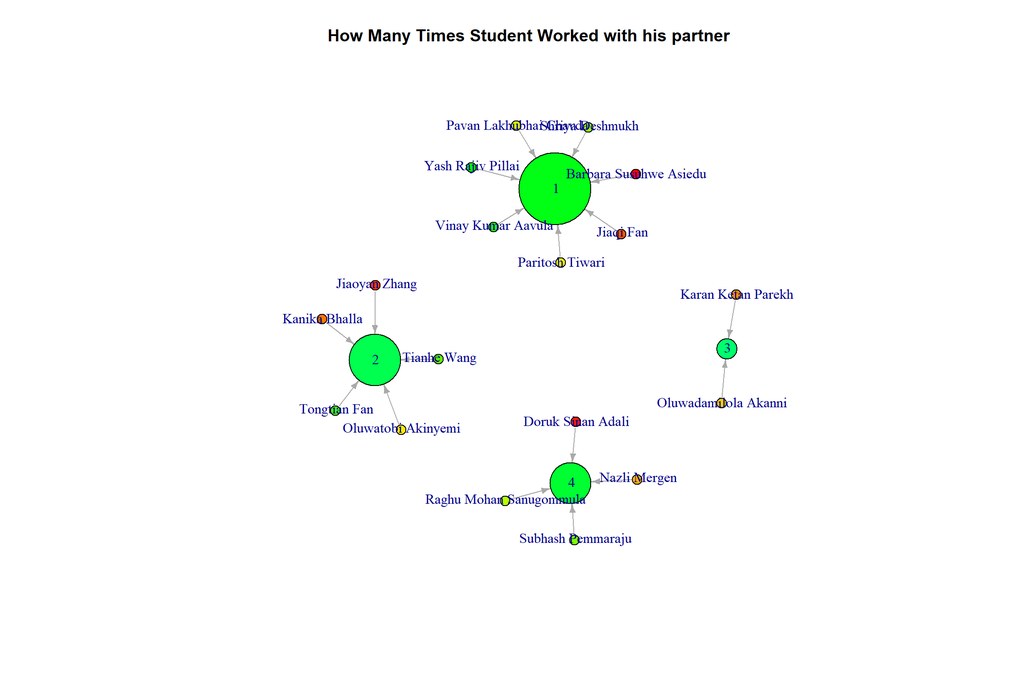

```r
Networkgraph3<-data.frame(dataset$What.is.YOUR.name.,dataset$Student.1..Number.times.you.worked.with.this.student.this.semester..enter.a.number.,dataset$Student.1..Is.this.student.male.or.female.)
network3<-graph.data.frame(Networkgraph3,directed=T)
V(network3)$degree<-degree(network3)
plot(network3, vertex.color=rainbow(52),vertex.size=V(network3)$degree*5,vertex.label.dist=0.1,edge.arrow.size=0.5,vertex.label.cex=1,layout=layout.fruchterman.reingold,main="How Many Times Student Worked with his partner")
```

**Figure 3**

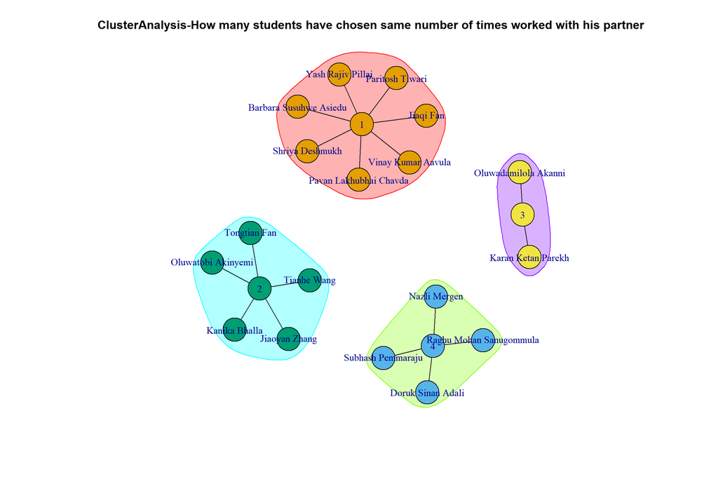

```r
network3dense<-graph.data.frame(Networkgraph3,directed=F)
  clusternest<-cluster_edge_betweenness(network3dense)
  plot(clusternest,network3dense,main="ClusterAnalysis-How many students have chosen same number of times worked with his partner",vertex.color=rainbow(52),layout=layout.fruchterman.reingold )
```

**Figure 4**

### Histogram

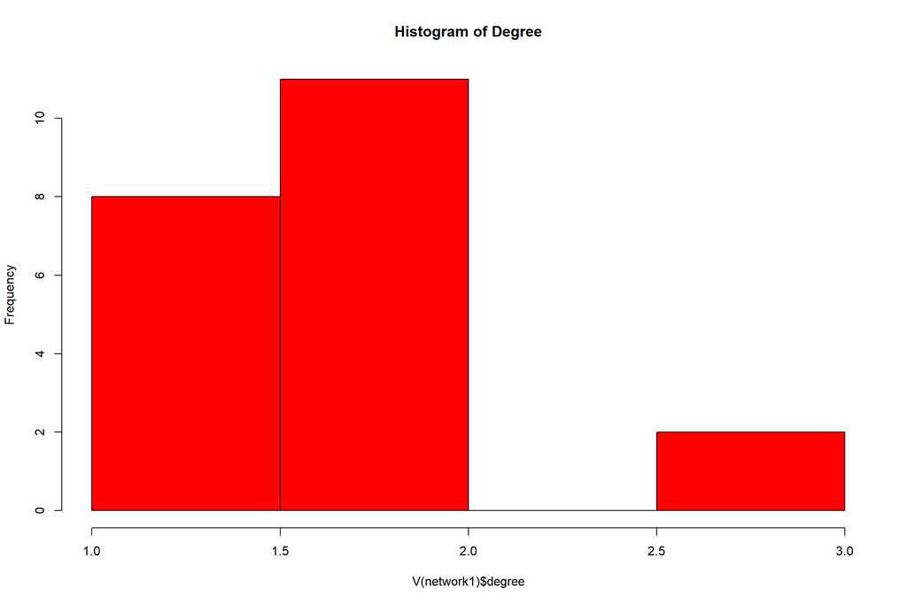

```r
hist(V(network1)$degree,col="red",main="Histogram of Degree",Xlab="Degree of Vertices",Ylab="Frequency")
```

**Figure 5-Histogram**

We have conducted more anlayis by taking the degree and plot the values on the histomgram. It seems like the degree of the connections fallen between 1 and 3 as shown in the figure. By looking at the graph it is clear most of the students has opted betwen 1 and 2.0 so we should be considered that has mode for this analysis by using the histogram.